# STSCI 4630 - Spring 2019 - HW5

Da (Harry) Lu, dl947

Due Tuesday, Mar/12/2019

# Question 1

[10 points] Adapt and run lines 1 to 11 for the stocks IBM (IBM), General Electric (GE), and Nike (NKE).

i) Report the second log gross return $r_5$ and the second net return $R_5$ for General Electric (GE). Are the values for $r_5$ and $R_5$ close? Explain this phenomenon briefly.

The log gross return $r_5$ of GE is -0.0053846, and the net return $R_5$ of GE is -0.0053702. The values are very close, because when $R_t$ is close to 0, we have $r_t\approx R_t$.

ii) Submit the output from lines 9 and 11.

```
##          IBM           GE          NKE
## 0.0003617045 0.0001891787 0.0007575329
```

|  | IBM | GE | NKE |
| --- | --- | --- | --- |
| IBM | 0.000183638 | 0.000132816 | 0.000108251 |
| GE | 0.000132816 | 0.000350152 | 0.000154219 |
| NKE | 0.000108251 | 0.000154219 | 0.000296547 |

iii) Report the sample mean for Nike (NKE).

The sample mean of NKE is 0.0007575.

iv) Report the sample variance for IBM (IBM).

The sample variance of IBM is 0.0001836.

v) Report the sample covariance between IBM (IBM) and General Electric (GE).

The sample covariance between IBM and GE is 0.0001328.

vi) Report the sample correlation between General Electric (GE) and Nike (NKE). (Hint: if you use the function `cor()`, submit your output.)

Using `cor()`:

```r
cor(R["GE"],R["NKE"])
```

```
##          NKE
## GE 0.4785886
```

Using the definition of correlation:

$$\text{Corr}(A,B)=\frac{\text{Cov}(A,B)}{\sqrt{\text{Var}(A)\cdot\text{Var}(B)}}$$

```r
cov_R["GE","NKE"]/sqrt(cov_R["GE","GE"]*cov_R["NKE","NKE"])
```

```
## [1] 0.4785886
```

# Question 2

[10 points] Run lines 12 and 13. Adapt and run lines 14 to 21 for the stocks IBM (IBM), General Electric (GE), and Nike (NKE) to find the smallest-risk portfolio having expected return $\mu_P=0.0006$.

i) Submit the output from lines 20 and 21.

```
##      [,1]
## [1,] "sigma_P"
## [2,] "0.0135527"
```

```
##      [,1]        [,2]         [,3]
## [1,] "w_1"       "w_2"        "w_3"
## [2,] "0.5541076" "-0.1087325" "0.5546249"
```

ii) Report the standard deviation of the smallest-risk portfolio having expected return $\mu_P=0.0006$.

The standard deviation is 0.0135527.

iii) Report the weight that is assigned to IBM (IBM) in the smallest-risk portfolio having expected return $\mu_P=0.0006$.

The weight of IBM is 0.5541076.

iv) Does the smallest-risk portfolio require shorting any of the assets? Explain your answer briefly.

It requires shorting GE because the weight is negative.

# Question 3

[10 points] Adapt and run lines 22 to 42 for the stocks IBM (IBM), General Electric (GE), and Nike (NKE). Use $k=2$.

```
##      [,1]
## [1,] "mu_MV"
## [2,] "0.0004433"
```

```
##      [,1]
## [1,] "sd_MV"
## [2,] "0.0126405"
```

```
##      [,1]        [,2]        [,3]
## [1,] "w_1_MV"    "w_2_MV"    "w_3_MV"
## [2,] "0.6511004" "0.0994791" "0.2494205"
```

i) Submit the plot of the efficient frontier.

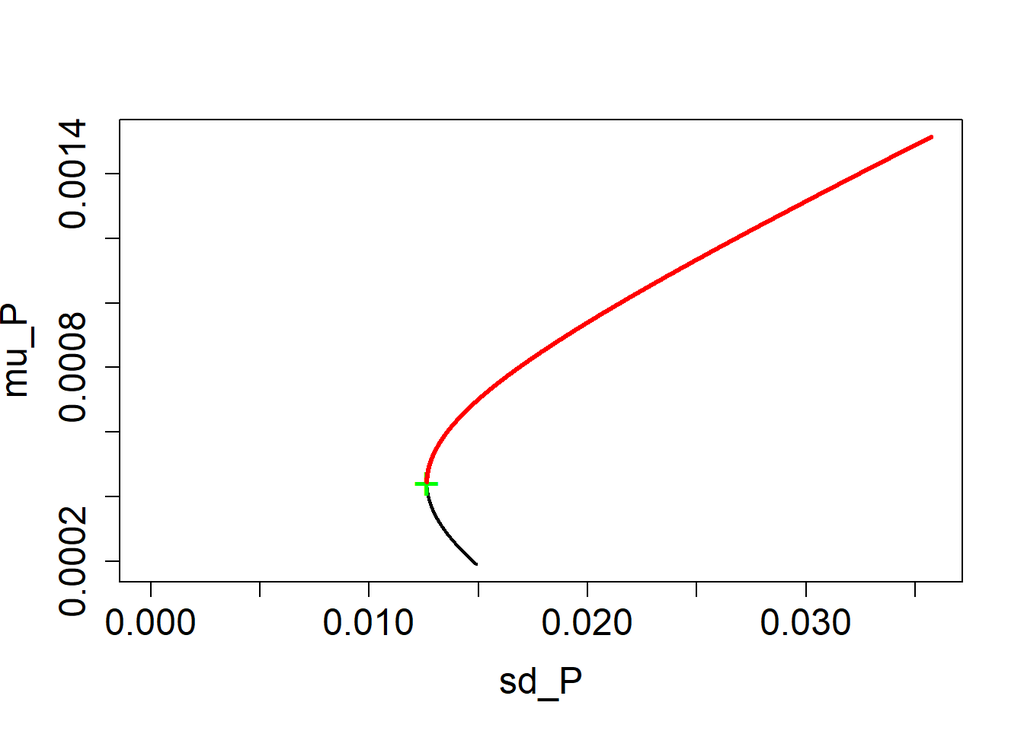

ii) Report the mean of the minimum-variance portfolio.

The mean is 0.0004433.

iii) Report the standard deviation of the minimum-variance portfolio.

The standard deviation is 0.0126405.

iv) Report the weights on the assets for the minimum-variance portfolio.

The weights are 0.6511004, 0.0994791 and 0.2494205.

# Question 4

[5 points] Adapt and run lines 43 to 49 for the stocks IBM (IBM), General Electric (GE), and Nike (NKE). Submit the plot of the weights as a function of the portfolio return.

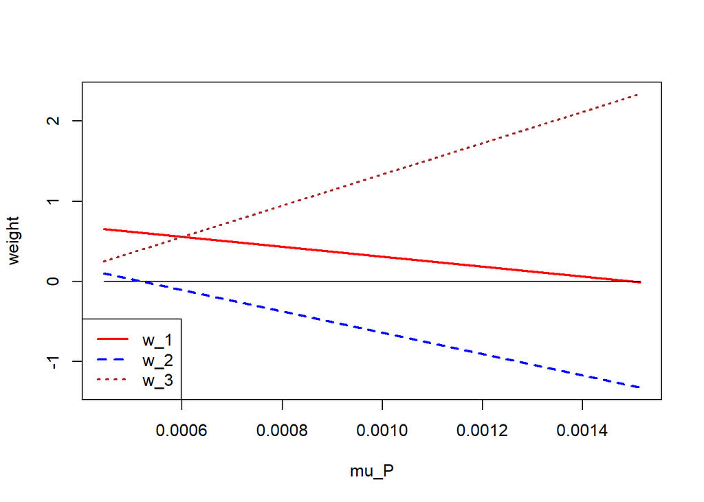

# Question 5

[10 points] Adapt and run lines 50 to 60 for the stocks IBM (IBM), General Electric (GE), and Nike (NKE) to find the smallest-risk portfolio having non-negative weights and expected return $\mu_P=0.0006$.

i) Submit the output from lines 59 and 60.

```
##      [,1]
## [1,] "sigma_P"
## [2,] "0.0137271"
```

```
##      [,1]        [,2]  [,3]
## [1,] "w_1"       "w_2" "w_3"
## [2,] "0.3979829" "0"   "0.6020171"
```

ii) Report the standard deviation of the smallest-risk portfolio having expected return $\mu_P=0.0006$.

The standard deviation is 0.0137271.

iii) Report the weight that is assigned to General Electric (GE) in the smallest-risk portfolio having expected return $\mu_P=0.0006$.

The weight of GE is 0.

iv) Does the smallest-risk portfolio require shorting any of the assets? Explain your answer briefly.

No, because there is no negative number.

# Question 6

[10 points] Adapt and run lines 61 to 84 for the stocks IBM (IBM), General Electric (GE), and Nike (NKE) to plot the efficient frontier under the constraint of non-negative weights. Re-run lines 43 to 49.

```
##      [,1]
## [1,] "mu_MV"
## [2,] "0.0004433"
```

```
##      [,1]
## [1,] "sd_MV"
## [2,] "0.0126405"
```

```
##      [,1]        [,2]      [,3]
## [1,] "w_1_MV"    "w_2_MV"  "w_3_MV"
## [2,] "0.6510915" "0.09946" "0.2494485"
```

i) Submit the plot of the efficient frontier.

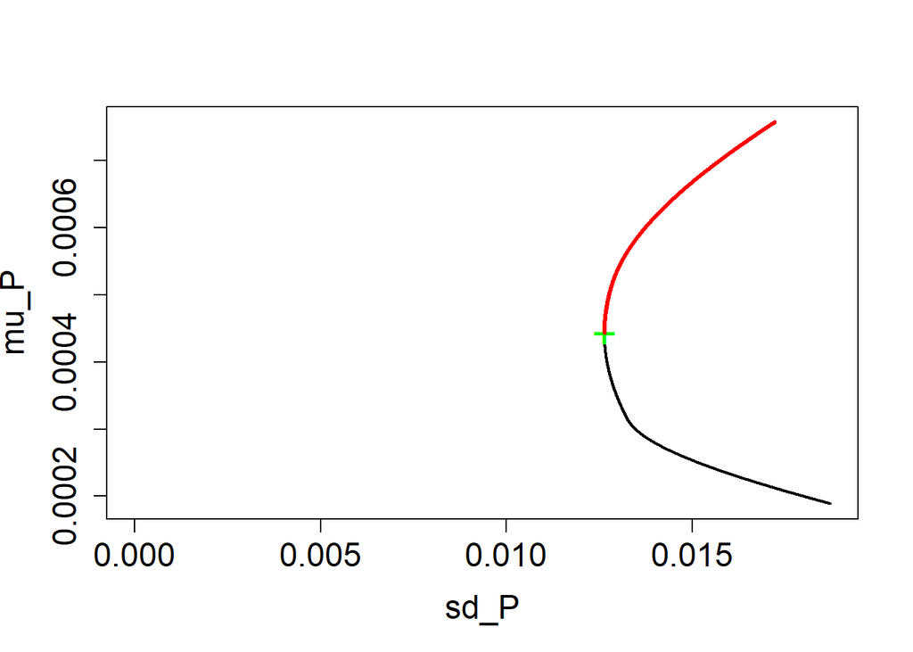

ii) Submit the plot of the weights.

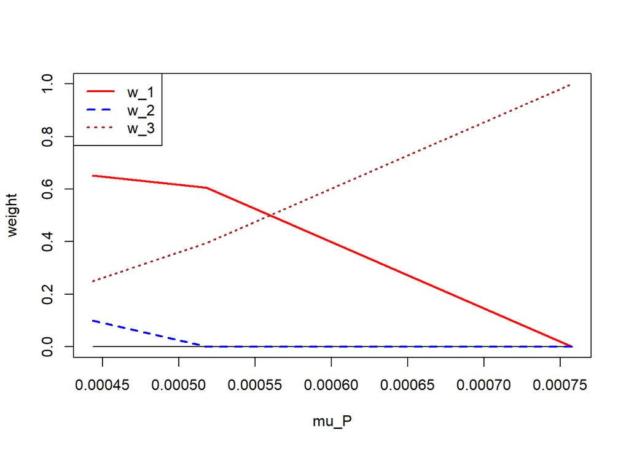

iii) Does the minimum-variance portfolio change when the condition of non-negative weights is imposed? Briefly explain why it does or does not change.

There is only a tiny change on the values (less than 0.1%). Since the mean and variance are not changed, and the original weights are all non-negative, the portfolio is not changed.

# Question 7

[10 points] Adapt and run lines 85 to 115 for the stocks IBM (IBM), General Electric (GE), and Nike (NKE) to plot the risk-return line of the optimal portfolios and to find the tangency portfolio in the case of a risk-free rate $\mu_f=0.0001$. Use $k=1.5$.

```
##      [,1]
## [1,] "mu_MV"
## [2,] "0.0004432"
```

```
##      [,1]
## [1,] "sd_MV"
## [2,] "0.0126405"
```

```
##      [,1]        [,2]        [,3]
## [1,] "w_1_MV"    "w_2_MV"    "w_3_MV"
## [2,] "0.6511141" "0.0995086" "0.2493772"
```

```
##      [,1]
## [1,] "mu_T"
## [2,] "0.000922"
```

```
##      [,1]
## [1,] "sd_T"
## [2,] "0.019562"
```

```
##      [,1]        [,2]         [,3]
## [1,] "w_1_T"     "w_2_T"      "w_3_T"
## [2,] "0.3548266" "-0.5365235" "1.1816969"
```

i) Submit the plot of the risk-return line.

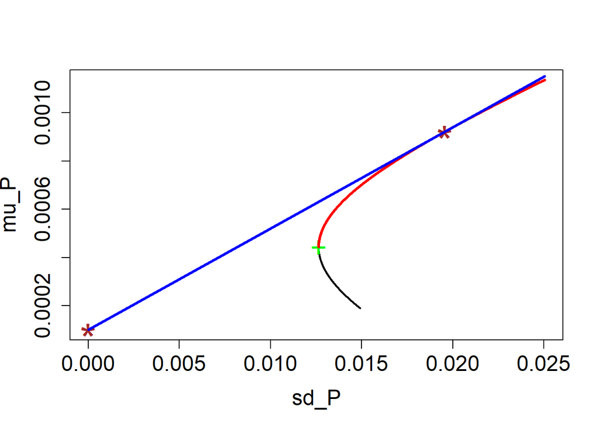

ii) Report the expected return of the tangency portfolio.

The expected return of the tangency portfolio is 0.000922.

iii) Report the standard deviation of the tangency portfolio.

The standard deviation of the tangency portfolio is 0.019562.

iv) Report the weights on the assets for the tangency portfolio. Are any of the assets shorted in the tangency portfolio?

The weights are 0.3548266, -0.5365235 and 1.1816969. Because the weight of GE is negative, it should be shorted.

# Question 8

[10 points] Adapt and run lines 116 to 121 for the stocks IBM (IBM), General Electric (GE), and Nike (NKE) to find the optimal portfolio having expected return $\mu_P=0.0006$ in the case of a risk-free rate $\mu_f=0.0001$.

i) Submit the output from lines 119, 120, and 121.

```
##      [,1]        [,2]
## [1,] "w_F"       "w_T"
## [2,] "0.3917407" "0.6082593"
```

```
##      [,1]
## [1,] "sd_O"
## [2,] "0.0118988"
```

```
##      [,1]        [,2]        [,3]         [,4]
## [1,] "w_F_O"     "w_1_O"     "w_2_O"      "w_3_O"
## [2,] "0.3917407" "0.2158266" "-0.3263454" "0.7187781"
```

ii) Report the standard deviation of the optimal portfolio having expected return $\mu_P=0.0006$.

The standard deviation is 0.0118988.

iii) Report the weight that is assigned to the risk-free asset in the optimal portfolio having expected return $\mu_P=0.0006$.

The weight of the risk-free asset is 0.3917407.

iv) Report the weights assigned to IBM (IBM), General Electric (GE), and Nike (NKE) in the optimal portfolio.

The weights are 0.2158266, -0.3263454 and 0.7187781.

# Question 9

[15 points] Adapt and run lines 122 to 155 for the stocks IBM (IBM), General Electric (GE), and Nike (NKE) to plot the risk-return line for the optimal portfolios and to find the tangency portfolio in the case of risk-free rate $\mu_f=0.0001$ under the constraint of non-negative weights on the assets.

```
##      [,1]
## [1,] "mu_MV"
## [2,] "0.0004433"
```

```
##      [,1]
## [1,] "sd_MV"
## [2,] "0.0126405"
```

```
##      [,1]        [,2]      [,3]
## [1,] "w_1_MV"    "w_2_MV"  "w_3_MV"
## [2,] "0.6510915" "0.09946" "0.2494485"
```

```
##      [,1]
## [1,] "mu_T"
## [2,] "0.0007318"
```

```
##      [,1]
## [1,] "sd_T"
## [2,] "0.0165291"
```

```
##      [,1]        [,2]    [,3]
## [1,] "w_1_T"     "w_2_T" "w_3_T"
## [2,] "0.0649139" "0"     "0.9350861"
```

i) Submit the plot of the risk-return line.

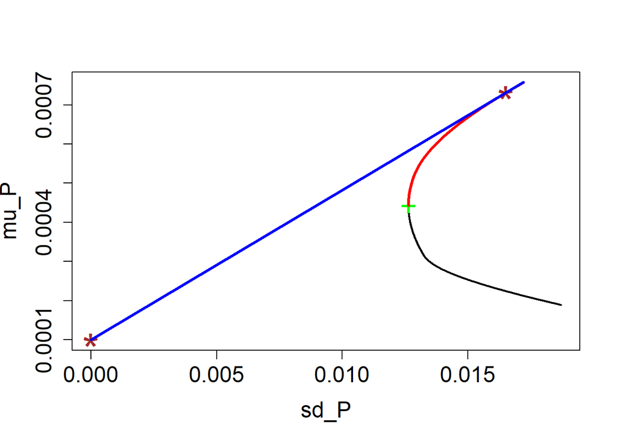

ii) Report the expected return of the tangency portfolio.

The expected return of the tangency portfolio is 0.0007318.

iii) Report the standard deviation of the tangency portfolio.

The standard deviation of the tangency portfolio is 0.0165291.

iv) Report the weights on the assets for the tangency portfolio.

The weights are 0.0649139, 0 and 0.9350861.

v) Compare the tangency portfolio for this question with that from Question 7. Explain the similarity or difference between the two tangency portfolios.

The weight of GE changes from negative number to 0.

vi) Adapt and run lines 116 to 121 to find the optimal portfolio having expected return $\mu_P=0.0006$ in the case of risk-free rate $\mu_f=0.0001$ under the constraint of non-negative weights on the assets. Include the output from line 120. By comparison with your answer to Question 8, what is the price of imposing non-negative weights?

```
##      [,1]        [,2]
## [1,] "w_F"       "w_T"
## [2,] "0.2086582" "0.7913418"
```

```
##      [,1]
## [1,] "sd_O"
## [2,] "0.0130802"
```

```
##      [,1]        [,2]       [,3]    [,4]
## [1,] "w_F_O"     "w_1_O"    "w_2_O" "w_3_O"
## [2,] "0.2086582" "0.051369" "0"     "0.7399728"
```

The risk increases since the standard deviation increases. Also the weight of risk-free asset decreases.

# Question 10

[10 points] Adapt and run lines 122 to 155 for the stocks IBM (IBM), General Electric (GE), and Nike (NKE) to plot the risk-return line for the optimal portfolios and to find the minimum variance and tangency portfolio in the case of risk-free rate $\mu_f=0.0001$ under the simultaneous constraints that i) all weights must be at least $-0.3$; and ii) the weight on IBM (IBM) is at most $0.4$.

```
A_neq=cbind(diag(1,nrow=N),diag(-1,nrow=N))
b_neq=c(-0.3,-0.3,-0.3,-0.4,-2,-2)
```

```
##      [,1]
## [1,] "mu_MV"
## [2,] "0.0004723"
```

```
##      [,1]
## [1,] "sd_MV"
## [2,] "0.013085"
```

```
##      [,1]     [,2]        [,3]
## [1,] "w_1_MV" "w_2_MV"    "w_3_MV"
## [2,] "0.4"    "0.2233217" "0.3766783"
```

```
##      [,1]
## [1,] "mu_T"
## [2,] "0.0007575"
```

```
##      [,1]
## [1,] "sd_T"
## [2,] "0.0160142"
```

```
##      [,1]    [,2]         [,3]
## [1,] "w_1_T" "w_2_T"      "w_3_T"
## [2,] "0.4"   "-0.2785787" "0.8785787"
```

```
##      [,1]        [,2]
## [1,] "w_F"       "w_T"
## [2,] "0.2395818" "0.7604182"
```

```
##      [,1]
## [1,] "sd_O"
## [2,] "0.0121775"
```

```
##      [,1]        [,2]        [,3]         [,4]
## [1,] "w_F_O"     "w_1_O"     "w_2_O"      "w_3_O"
## [2,] "0.2395818" "0.3041673" "-0.2118363" "0.6680872"
```

i) Submit the plot of the risk-return line.

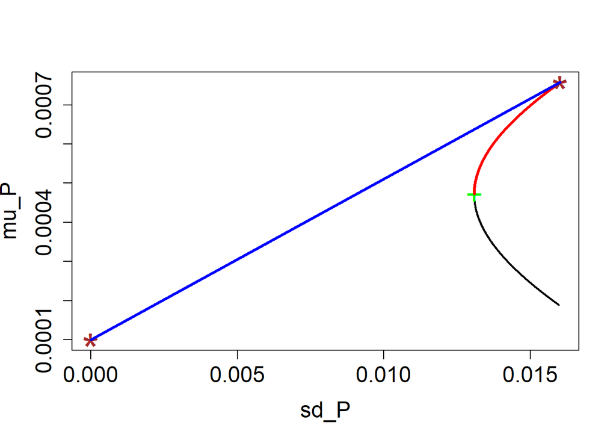

ii) Submit the plot of the weights.

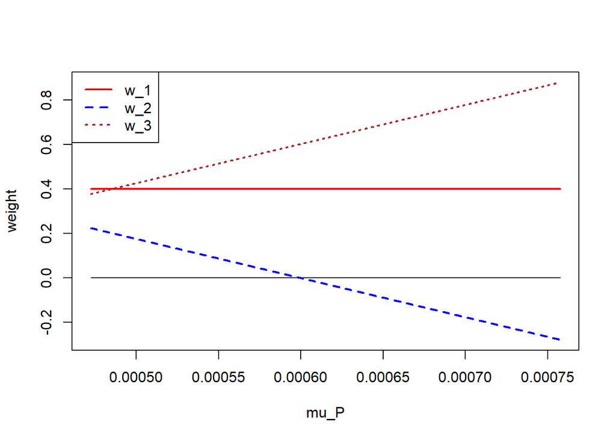

iii) Report the expected return of the minimum-variance portfolio.

The expected return of the minimum-variance portfolio is 0.0004723.

iv) Report the standard deviation of the minimum-variance portfolio.

The standard deviation of the minimum-variance portfolio is 0.013085.

v) Report the expected return of the tangency portfolio.

The expected return of the tangency portfolio is 0.0007575.

vi) Report the standard deviation of the tangency portfolio.

The standard deviation of the tangency portfolio is 0.0160142.

vii) What is the standard deviation of the optimal portfolio having expected return $\mu_P=0.0006$ in the case of risk-free rate $\mu_f=0.0001$ under the present constraints on the weights on the assets.

The standard deviation of the optimal portfolio is 0.0121775.